# Does transmission type affect car fuel economy

mbh038

Monday, June 15, 2015

## Executive Summary

We perform an anlysis to answer the question of the title, using the mtcars data set, and using gallons per 100 miles (gpm) as an inverse metric of fuel economy, rather then mpg. Simple physics considerations suggest that many factors might affect fuel economy, besides transmission type and correlation of several factors is indeed confirmed by an exploratory pairs plot. An initial regression of gpm with transmission type, displacement, gross horsepower, weight and time to reach a quarter mile distance suggested that only weight was a significant predictor of fuel economy. A subsequent regression of fuel economy on ony weight and transmission type confirmed this. The analysis cannot exclude the possibility that transmission type makes no difference to fuel economy (P=0.2)

## Load the data

```r
library(dplyr)
```

```r
library(ggplot2)
data(mtcars)
str(mtcars)
```

```
## 'data.frame':    32 obs. of  11 variables:
##  $ mpg : num  21 21 22.8 21.4 18.7 18.1 14.3 24.4 22.8 19.2 ...
##  $ cyl : num  6 6 4 6 8 6 8 4 4 6 ...
##  $ disp: num  160 160 108 258 360 ...
##  $ hp  : num  110 110 93 110 175 105 245 62 95 123 ...
##  $ drat: num  3.9 3.9 3.85 3.08 3.15 2.76 3.21 3.69 3.92 3.92 ...
##  $ wt  : num  2.62 2.88 2.32 3.21 3.44 ...
##  $ qsec: num  16.5 17 18.6 19.4 17 ...
##  $ vs  : num  0 0 1 1 0 1 0 1 1 1 ...
##  $ am  : num  1 1 1 0 0 0 0 0 0 0 ...
##  $ gear: num  4 4 4 3 3 3 3 4 4 4 ...
##  $ carb: num  4 4 1 1 2 1 4 2 2 4 ...
```

## Pre-processing of the data

To determine whether the transmission type of the cars has a significant effect on their fuel economy, we first express the latter as “gallons per 100 miles” variable, named gpm, which is an inverse measure to mpg that is commonly used in many countries. It is more likely than mpg to have a linear relationship with factors affecting fuel economy, and so is a more suitable input to a linear regression analysis. We also convert the transmission type column to a factor type.

```r
for (i in c(2,8,9,10,11)){mtcars[,i]=factor(mtcars[,i])}
mtcars$gpm<-100/mtcars$mpg
```

A pairs plot was created for those variables that on physical grounds we suspect might influence the fuel economy of the cars, that is disp (displacement), hp (gross horsepower), wt (weight), qsec (time to reach a quarter mile distance)

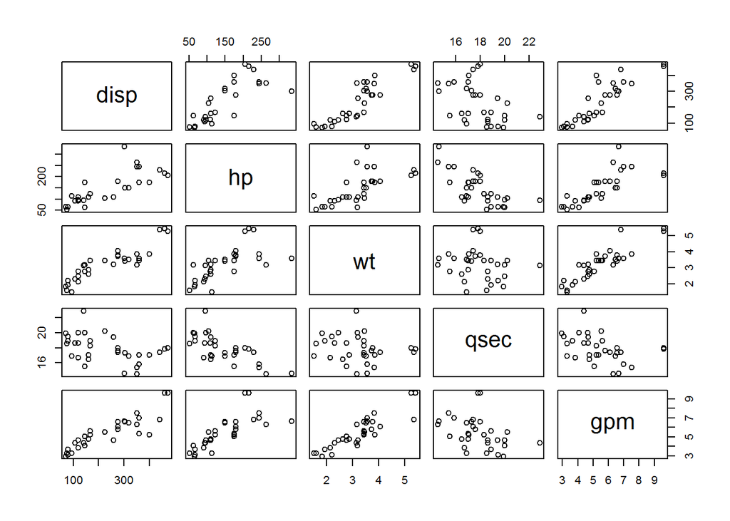

```r
pairs(mtcars[,-c(1,2,5,8,9,10,11)])
```

This suggests that all the above mentioned variables are correlated with fuel economy. hence, in a first regression analysis, all will first be inclued as regressors,together with the transmission type.

## First regression analysis

```r
fit<-lm(gpm~factor(am)+wt+disp+qsec+hp-1,data=mtcars)
summary(fit)
```

```
##
## Call:
## lm(formula = gpm ~ factor(am) + wt + disp + qsec + hp - 1, data = mtcars)
##
## Residuals:
##      Min       1Q   Median       3Q      Max
## -1.67672 -0.31314 -0.00921  0.37421  1.32098
##
## Coefficients:
##              Estimate Std. Error t value Pr(>|t|)
## factor(am)0  2.550543   2.735011   0.933  0.35963
## factor(am)1  2.586791   2.520657   1.026  0.31423
## wt           1.095920   0.335278   3.269  0.00304 **
## disp         0.001905   0.002977   0.640  0.52782
## qsec        -0.091819   0.133492  -0.688  0.49765
## hp           0.003619   0.004073   0.889  0.38233
## ---
## Signif. codes:  0 '***' 0.001 '**' 0.01 '*' 0.05 '.' 0.1 ' ' 1
##
## Residual standard error: 0.6821 on 26 degrees of freedom
## Multiple R-squared:  0.9882, Adjusted R-squared:  0.9855
## F-statistic: 362.7 on 6 and 26 DF,  p-value: < 2.2e-16
```

```r
confint(fit)
```

```
##                    2.5 %      97.5 %
## factor(am)0 -3.071353423 8.172438433
## factor(am)1 -2.594494883 7.768076279
## wt           0.406746212 1.785094586
## disp        -0.004214539 0.008024878
## qsec        -0.366214699 0.182577086
## hp          -0.004752170 0.011990584
```

The intercept was excluded in the above analysis, so each of the estimate values in the summary above represent the amount by which the fuel economy, as expressed by gpm, will change, per unit change in the variate with all the other variates included in the regression being held constant. of all the continuous variables, ony weight appears to be statisitically significant factor.It is the only one with a P value less than 0.05, and the only for which the confidence interval does not straddles zero.

## Second regresssion analysis

Given the result above, we perform a second regression, including only transmission type and weight as regressors, with gpm as the response.

```r
fit<-lm(gpm~factor(am)+wt,data=mtcars)
summary(fit)
```

```
##
## Call:
## lm(formula = gpm ~ factor(am) + wt, data = mtcars)
##
## Residuals:
##      Min       1Q   Median       3Q      Max
## -1.96508 -0.40647  0.03359  0.48148  1.25581
##
## Coefficients:
##             Estimate Std. Error t value Pr(>|t|)
## (Intercept)  -0.1280     0.7430  -0.172    0.864
## factor(am)1   0.4830     0.3759   1.285    0.209
## wt            1.6643     0.1917   8.681 1.47e-09 ***
## ---
## Signif. codes:  0 '***' 0.001 '**' 0.01 '*' 0.05 '.' 0.1 ' ' 1
##
## Residual standard error: 0.7535 on 29 degrees of freedom
## Multiple R-squared:  0.8031, Adjusted R-squared:  0.7895
## F-statistic: 59.15 on 2 and 29 DF,  p-value: 5.836e-11
```

```r
confint(fit)
```

```
##                  2.5 %   97.5 %
## (Intercept) -1.6475534 1.391487
## factor(am)1 -0.2859234 1.251829
## wt           1.2722182 2.056437
```

This result show that we cannot infer from thse data that tranmssion type affects feul economy, while vehicle weight certainly does. The estimated gpm value for manual transmission at zero ocar weight is 0.483 more than for automatic transmissions, but with a P value of 0.2 we cannot exclude the possibility that this diofference is zero. Indeed we see this also from the confidence interval for manual transmission. It straddles zero, meaning that we cannot be 95% confident that the fuel economy is greater or less for manual transmision compared to automatic transmission.

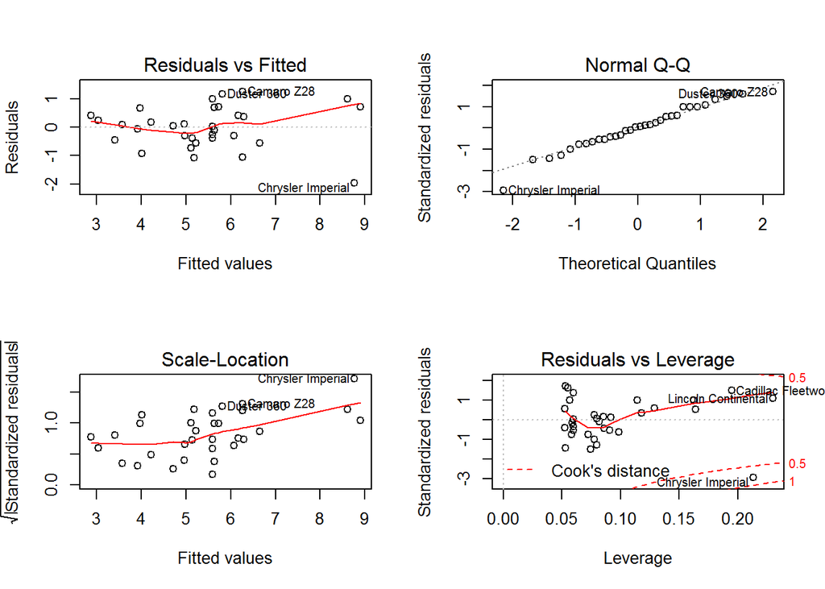

```r
par(mfrow=c(2,2))
plot(fit)
```

There is no systematic variation in the residuals, and thr qq plot is linear, suggesting that the data set is normally distributed around the fit, and hence that the above analysis is valid.

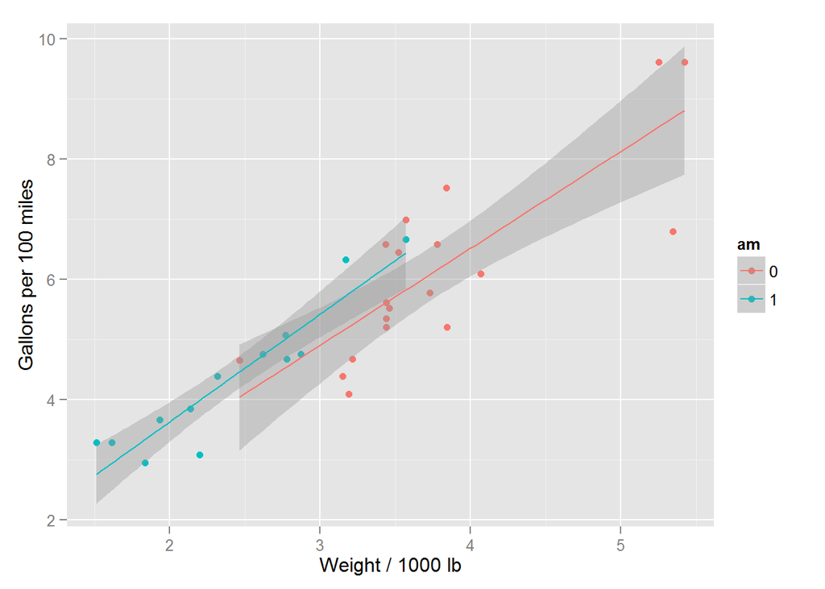

```r
library(ggplot2)
mtcars$gpm<-100/mtcars$mpg
g<-ggplot(data=mtcars,aes(x=wt,y=gpm,colour=am))+
        geom_point()+
        geom_smooth(method=lm)+
        #facet_wrap(~amf,shrink=FALSE)+
        labs(x = "Weight / 1000 lb",y = "Gallons per 100 miles")
g
```